# Blood correction

Blood in a biopsy dilutes the muscle proteins, so many proteins rise or fall with the blood index. The comparisons carry the index as a covariate. Some later methods cannot: module building, set scores and correlations. They read a copy of the protein values with each protein’s blood slope removed. This step builds that copy, after testing three ways to remove the slope.

## Packages

```r
library(here)
library(limma)
library(dplyr)
library(ggplot2)
source(here("00_Setup", "Shared_functions", "workbooks.R"))
inputs <- c(proteins = "01_Processing/02_Quantification/c_data/quantification.rds")
paths <- vapply(inputs, here, character(1))
stopifnot(file.exists(paths))
```

## Input

limpa’s protein values: complete log2 values, a standard error for each, and per value the number of observed precursors (`other$n.observations`). A value with no observed precursor was estimated from the detection curve.

```r
proteins <- readRDS(paths[["proteins"]])
blood <- proteins$targets$blood
observed <- proteins$other$n.observations > 0
time_design <- model.matrix(~ 0 + timepoint, proteins$targets)
design <- cbind(time_design, blood = blood)
c(
  proteins = nrow(proteins), biopsies = ncol(proteins),
  pct_estimated = round(100 * mean(!observed), 1)
)
```

```
     proteins      biopsies pct_estimated
       2059.0          48.0          17.7
```

## Three ways to remove the slope

Each fits protein ~ time point + blood and subtracts the blood term, so time differences are kept. They differ in which values the slope is fitted on and removed from:

- **a, all values**: `limma::removeBatchEffect()` fits and removes on every value, observed or estimated.
- **b, observed values only**: `lmFit()` with weight 1 on observed values and 0 on estimated ones, so the slope is fitted on observed values only, and it is removed from them; estimated values are left as limpa made them.
- **c, precision-weighted**: `lmFit()` with weights 1/SE², removed from every value.

```r
variant_a <- removeBatchEffect(proteins$E, covariates = blood, design = time_design)
weighted <- lmFit(proteins$E, design, weights = 1 / proteins$other$standard.error^2)
variant_c <- proteins$E - outer(weighted$coefficients[, "blood"], blood)
observed_fit <- lmFit(proteins$E, design, weights = 1 * observed)
variant_b <- proteins$E - outer(observed_fit$coefficients[, "blood"], blood) * observed
```

## Which one works

A correction works if it lowers each protein’s correlation with blood. The check is the median absolute Spearman correlation with the blood index, by how many biopsies observed the protein. The rule, set before looking: keep the variant that lowers it in every band.

```r
band <- cut(rowSums(observed), c(0, 20, 39, ncol(proteins)), labels = c("<=20", "21-39", ">=40"))
blood_rho <- \(values) abs(apply(values, 1, \(x) cor(x, blood, method = "spearman")))
check <- list(
  uncorrected = proteins$E, a_all_values = variant_a, b_observed_only = variant_b,
  c_precision_weighted = variant_c
) |>
  vapply(\(values) tapply(blood_rho(values), band, median), numeric(3)) |>
  as_tibble(rownames = "observed_in") |>
  mutate(n_proteins = as.vector(table(band)), .after = observed_in)
check
```

```
# A tibble: 3 × 6
  observed_in n_proteins uncorrected a_all_values b_observed_only
  <chr>            <int>       <dbl>        <dbl>           <dbl>
1 <=20               209       0.145       0.413           0.134
2 21-39              477       0.151       0.111           0.117
3 >=40              1373       0.137       0.0872          0.0891
# ℹ 1 more variable: c_precision_weighted <dbl>
```

```r
passes <- vapply(
  c("a_all_values", "b_observed_only", "c_precision_weighted"),
  \(v) all(check[[v]] < check$uncorrected), logical(1)
)
passes
```

```
        a_all_values      b_observed_only c_precision_weighted
               FALSE                 TRUE                FALSE
```

```r
stopifnot(passes[["b_observed_only"]])
```

Variants a and c raise the blood correlation of sparsely observed proteins: their slope is fitted mostly on estimated values, which do not carry the protein’s blood relationship, and subtracting it adds blood signal. Variant b lowers the correlation in every band and is kept.

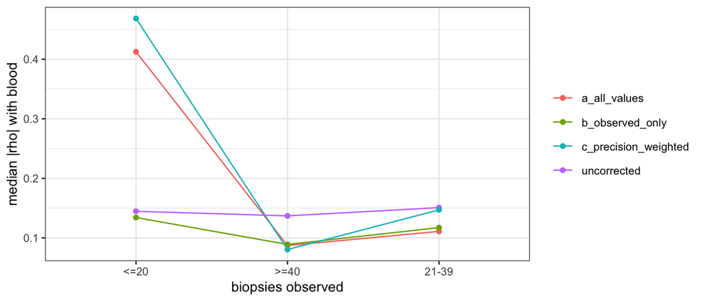

Figure 1: Median |Spearman rho| with the blood index, by detection band and variant.

```r
check |>
  tidyr::pivot_longer(-c(observed_in, n_proteins), names_to = "variant", values_to = "rho") |>
  ggplot(aes(observed_in, rho, colour = variant, group = variant)) +
  geom_line() +
  geom_point() +
  labs(x = "biopsies observed", y = "median |rho| with blood", colour = NULL) +
  theme_bw(base_size = 10)
```

## Validation

```r
stopifnot(
  !anyNA(variant_b), identical(dim(variant_b), dim(proteins$E)),
  all(variant_b[!observed] == proteins$E[!observed])
)
```

## Save

`blood_correction.rds` is the protein `EList` with `E` replaced by variant b; standard errors, annotation and biopsy table are unchanged.

```r
corrected <- proteins
corrected$E <- variant_b
out <- here("01_Processing", "03_Blood_Correction", "c_data")
dir.create(out, showWarnings = FALSE)
saveRDS(corrected, file.path(out, "blood_correction.rds"))
write_workbook(
  list(blood_check = check),
  "Median |Spearman rho| with the blood index by detection band, uncorrected and three variants.",
  file.path(out, "blood_correction.xlsx"), inputs, paths
)
```